# Aufgabenblatt 8

## Statistik für Wirtschaftsinformatiker, Übung, HTW Berlin

### Martin Spott, Michael Heimann

Stand: 26.05.2024

## Wiederholung

Diese Fragen beziehen sich auf qualitative Merkmale

- Was bedeutet es, wenn zwei Merkmale *unabhängig* voneinander sind?
- Was sind die *erwarteten Häufigkeiten im Falle von Unabhängigkeit* und wie berechnet man sie?
- Wie kann man den Grad der Unabhängigkeit messen?

## Aufgabe 8.1

Wir benutzen die Daten von Aufgabe 7.1 (Aufgabenblatt 7):

```r
library(knitr)
betriebe_daten <- matrix(c(639,64,41,487,131,41,203,153,33,54,91,17,46,112,18),
               nrow=5, ncol=3, byrow=T,
               dimnames=list(c("[0,50)", "[50, 180)",
                  "[180, 500)", "[500, 1000)", ">= 1000"),
                c("Vollzeit", "Nebenerwerb", "Pacht")))

library(knitr)
library(vcd)
library(DescTools)
kable(betriebe_daten)
```

|  | Vollzeit | Nebenerwerb | Pacht |
| --- | --- | --- | --- |
| [0,50) | 639 | 64 | 41 |
| [50, 180) | 487 | 131 | 41 |
| [180, 500) | 203 | 153 | 33 |
| [500, 1000) | 54 | 91 | 17 |
| >= 1000 | 46 | 112 | 18 |

1. Berechnen Sie Pearsons $\chi^2$-Statistik, den $\Phi$-Koeffizienten, das Kontingenzmaß C nach Pearson und das Kontingenzmaß V nach Cramer aus der Tabelle mit R. Benutzen Sie dazu die Funktion `assocstats()` der Bibliothek `vcd` oder die Funktionen `Phi()`, `ContCoef()` oder `CramerV()` der Bibliothek `DescTools`.

```r
# Berechnung von Pearsons Chi-Quadrat-Statistik
chi2 <- chisq.test(betriebe_daten)

# Phi-Koeffizient
phi <- Phi(betriebe_daten)

# Kontingenzmaß C nach Pearson
cont_coef <- ContCoef(betriebe_daten)

# Kontingenzmaß V nach Cramer
cramer_v <- CramerV(betriebe_daten)

# Ergebnisse ausgeben
chi2$expected
```

```
            Vollzeit Nebenerwerb    Pacht
[0,50)      499.1437   192.46197 52.39437
[50, 180)   442.1178   170.47371 46.40845
[180, 500)  260.9770   100.62864 27.39437
[500, 1000) 108.6845    41.90704 11.40845
>= 1000     118.0770    45.52864 12.39437
```

```r
phi
```

```
[1] 0.4410642
```

```r
cont_coef
```

```
[1] 0.4035542
```

```r
cramer_v
```

```
[1] 0.3118795
```

2. Berechnen Sie die Kontingenztabelle für die erwarteten absoluten Häufigkeiten, die im Falle der Unabhängigkeit von Betriebsgröße und Betriebsführung auftreten würden.

```r
expected <- chi2$expected

# Tabelle anzeigen
expected
```

```
            Vollzeit Nebenerwerb    Pacht
[0,50)      499.1437   192.46197 52.39437
[50, 180)   442.1178   170.47371 46.40845
[180, 500)  260.9770   100.62864 27.39437
[500, 1000) 108.6845    41.90704 11.40845
>= 1000     118.0770    45.52864 12.39437
```

3. Berechnen Sie die Kontingenztabelle für die erwarteten relativen Häufigkeiten, die im Falle der Unabhängigkeit von Betriebsgröße und Betriebsführung auftreten würden.

```r
relative_expected <- expected / sum(betriebe_daten)

# Tabelle anzeigen
relative_expected
```

```
              Vollzeit Nebenerwerb       Pacht
[0,50)      0.23433975  0.09035773 0.024598294
[50, 180)   0.20756706  0.08003461 0.021788005
[180, 500)  0.12252441  0.04724349 0.012861205
[500, 1000) 0.05102559  0.01967467 0.005356080
>= 1000     0.05543521  0.02137495 0.005818951
```

4. Erzeugen Sie einen Mosaikplot der Originaltabelle und der Tabelle mit den erwarteten Häufigkeiten und vergleichen Sie sie. Beschreiben und erklären Sie die Unterschiede.

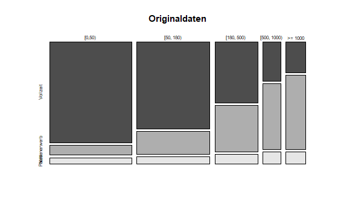

```r
# Mosaikplot der Originaltabelle
mosaicplot(betriebe_daten, main = "Originaldaten", color = TRUE)
```

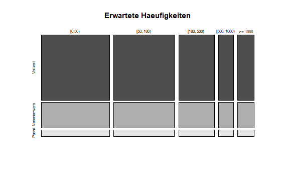

```r
# Mosaikplot der erwarteten Häufigkeiten
mosaicplot(expected, main = "Erwartete Haeufigkeiten", color = TRUE)
```

5. Was sind die Werte von Pearsons $\chi^2$-Statistik, dem $\Phi$-Koeffizienten und des Kontingenzmaßes V nach Cramer für die Tabelle mit den erwarteten Häufigkeiten?

```r
# Chi-Quadrat-Test für erwartete Häufigkeiten
chi2_expected <- chisq.test(expected)

# Phi-Koeffizient
phi_expected <- Phi(expected)

# Kontingenzmaß C nach Pearson
cont_coef_expected <- ContCoef(expected)

# Kontingenzmaß V nach Cramer
cramer_v_expected <- CramerV(expected)

# Ergebnisse ausgeben
chi2_expected
```

```
    Pearson's Chi-squared test

data:  expected
X-squared = 0, df = 8, p-value = 1
```

```r
phi_expected
```

```
[1] 0
```

```r
cont_coef_expected
```

```
[1] 0
```

```r
cramer_v_expected
```

```
[1] 0
```

6. (Zusatzaufgabe) Berechnen Sie Pearsons $\chi^2$-Statistik, den $\Phi$-Koeffizienten und das Kontingenzmaß V nach Cramer aus Aufgabe c) händisch in R, in dem Sie die Formeln der Maße in R umsetzen.

```r
# Chi-Quadrat-Statistik händisch berechnen
observed <- betriebe_daten
expected <- chi2$expected
chi2_manual <- sum((observed - expected)^2 / expected)

# Gesamtanzahl der Beobachtungen
n <- sum(observed)

# Anzahl der Zeilen und Spalten
k <- min(nrow(observed), ncol(observed))

# Phi-Koeffizient händisch berechnen
phi_manual <- sqrt(chi2_manual / n)

# Cramers V händisch berechnen
cramer_v_manual <- sqrt(chi2_manual / (n * (k - 1)))

# Ergebnisse ausgeben
chi2_manual
```

```
[1] 414.3651
```

```r
phi_manual
```

```
[1] 0.4410642
```

```r
cramer_v_manual
```

```
[1] 0.3118795
```

## Aufgabe 8.2

Benutzen Sie die Daten von Aufgabe 7.4 bezüglich der Wirkung einer Hautsalbe (Aufgabenblatt 7).

```r
daten <- matrix(c(223, 75, 107, 21), nrow=2, byrow=T,
                dimnames=list(c("mit Creme","ohne Creme"),
                              c("besser","schlechter")))

kable(daten)
```

|  | besser | schlechter |
| --- | --- | --- |
| mit Creme | 223 | 75 |
| ohne Creme | 107 | 21 |

1. Berechnen Sie die bedingten relativen Häufigkeiten $f(\text{Salbe verwendet} | \text{Ausschlag besser})$ und $f(\text{Salbe nicht verwendet} | \text{Ausschlag besser})$. Sagen diese beiden Häufigkeiten etwas darüber aus, ob die Anwendung der Salbe sinnvoll ist oder nicht? Interpretieren Sie die Ergebnisse.

```r
# Bedingte relative Häufigkeiten
f_creme_besser <- daten["mit Creme", "besser"] / sum(daten[, "besser"])
f_ohne_creme_besser <- daten["ohne Creme", "besser"] / sum(daten[, "besser"])

# Ergebnisse ausgeben
f_creme_besser
```

```
[1] 0.6757576
```

```r
f_ohne_creme_besser
```

```
[1] 0.3242424
```

2. Berechnen Sie die Kontingenztabelle für die erwarteten absoluten Häufigkeiten, die im Falle der Unabhängigkeit von Benutzung der Salbe und Hautausschlag auftreten würden.

```r
# Erwartete absolute Häufigkeiten berechnen
chisq_test <- chisq.test(daten)
expected <- chisq_test$expected

# Tabelle anzeigen
kable(expected)
```

|  | besser | schlechter |
| --- | --- | --- |
| mit Creme | 230.84507 | 67.15493 |
| ohne Creme | 99.15493 | 28.84507 |

```r
NA
```

3. Berechnen Sie Pearsons $\chi^2$-Statistik, den $\Phi$-Koeffizienten, das Kontingenzmaß C nach Pearson und das Kontingenzmaß V nach Cramer. Benutzen Sie dazu die Funktion `assocstats()` der Bibliothek `vcd`. Was sagen uns die berechneten Werte bezüglich des Grades der Unabhängigkeit?

```r
# Bibliotheken laden
library(vcd)

# Berechnung der Assoziationsstatistiken
assoc_stats <- assocstats(daten)

# Ergebnisse ausgeben
assoc_stats
```

```
                    X^2 df P(> X^2)
Likelihood Ratio 4.1160  1 0.042480
Pearson          3.9374  1 0.047223

Phi-Coefficient   : 0.096
Contingency Coeff.: 0.096
Cramer's V        : 0.096
```

4. Betrachten Sie folgende veränderte Kontingenztabelle:

```r
daten2 <- matrix(c(298, 0, 0, 128), nrow=2, byrow=T,
                 dimnames=list(c("mit Creme","ohne Creme"),
                               c("besser","schlechter")))

kable(daten2)
```

[output not shown]

Interpretieren Sie die Tatsache, dass zwei der Werte Null sind. Berechnen Sie Pearsons $\chi^2$-Statistik, den $\Phi$-Koeffizienten und das Kontingenzmaß V nach Cramer und machen Sie sich die Werte klar.

```r
# Berechnung von Pearsons Chi-Quadrat-Statistik
chisq_test2 <- chisq.test(daten2, correct = FALSE)

# Ergebnisse ausgeben
chisq_test2$statistic
```

```
X-squared
      426
```

```r
chisq_test2$p.value
```

```
[1] 1.206416e-94
```

```r
# Berechnung des Phi-Koeffizienten
phi2 <- Phi(daten2)

# Ergebnis ausgeben
phi2
```

```
[1] 1
```

```r
# Berechnung von Cramers V
cramer_v2 <- CramerV(daten2)

# Ergebnis ausgeben
cramer_v2
```

```
[1] 1
```